# Week 2 Exercise 1

Kendra

2/24/2020

Set Up

Loading and preprocessing the data

```r
Url <- "https://d396qusza40orc.cloudfront.net/repdata%2Fdata%2Factivity.zip"
download.file(Url, destfile = paste0(getwd(), '/repdata%2Fdata%2Factivity.zip'), method = "curl")
unzip("repdata%2Fdata%2Factivity.zip",exdir = "data")
data <- read.csv("data/activity.csv")
data$date <- as.Date(data$date)
```

# What is the mean total number of steps taken per day?

Calculate the total number of steps per day

```r
stepsday <- aggregate(data$steps ~ data$date, FUN=sum, )
colnames(stepsday) <- c("Date", "sum")
totalsteps <- sum(stepsday$sum)
```

Histogram of total number of steps per day.

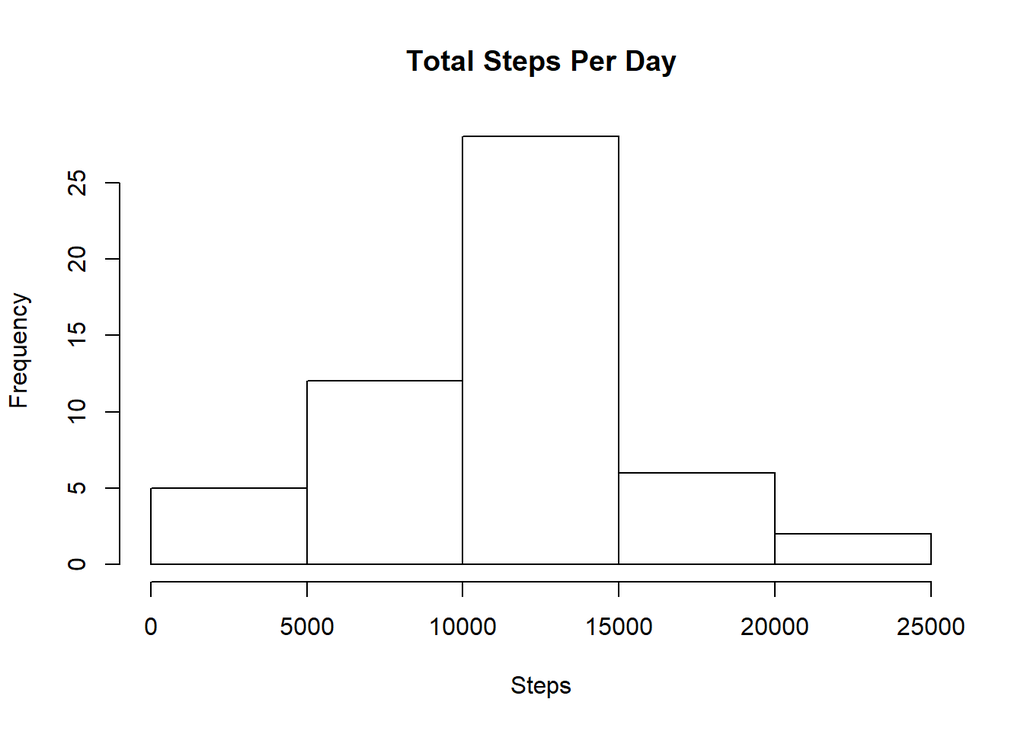

```r
hist(stepsday$sum, breaks = 5, xlab = "Steps", ylab = "Frequency", main = "Total Steps Per Day")
```

Mean and Median of total number of steps per day.

```r
meansteps <- as.integer(mean(stepsday$sum, na.rm = TRUE))
mediansteps <- median(stepsday$sum)
```

The total number of steps is 570608. The mean number of steps per day is 10766. The median number of steps per day is 10765.

# What is the average daily activity pattern?

Make a time series plot of 5 minute interval and average number of steps.

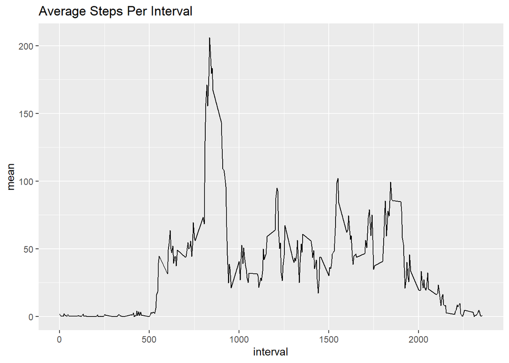

```r
fiveminutes <- group_by(data, interval) %>% summarize(mean = mean(steps, na.rm = TRUE))
ggplot(fiveminutes, aes(interval, mean), ylab = "Average Steps")+
  geom_line()+
  ggtitle("Average Steps Per Interval")
```

Which five minute interval contains the max number of steps?

```r
maxminute <- fiveminutes$interval[which.max(fiveminutes$mean)]
```

The 5-minute interval with the maximum number of steps on average is 835.

# Inputing Missing Values

Calculate number of missing values.

```r
summissing <- sum(is.na(data$steps))
```

The total number of rows with missing values for steps is 2304.

Create a dataset with missing data filled in.

```r
missing <- data[!is.na(data$steps),]
##Create dataset with all NA values, fill with 5 min interval averages
thena <- data[is.na(data$steps),] %>% merge(fiveminutes, by.x = "interval", by.y = "interval")
##Arrange properly
thena <- thena[,c(4,3,1)]
colnames(thena) <- c("steps", "date", "interval")
##Combine
together <- rbind(missing, thena)
```

Create histogram

[figure not shown]

```r
hist(stepsday$sum, breaks = 5, xlab = "Steps", ylab = "Frequency", main = "Total Steps Per Day, Adjusted")
```

Calculate Mean and Median

```r
meana <- as.integer((mean(together$steps)))
mediana <- as.integer((median(together$steps)))
```

The new mean is 37. The new median is 0.

# Are there differences in activity patterns between weekdays and weekends?

Create a new factor: “Weekday” and “weekend”.

```r
weekdaysdef <- c("Monday", "Tuesday", "Wednesday", "Thursday", "Friday")
together$weekday <- factor(weekdays(as.Date(together$date)) %in% weekdaysdef, levels=c(FALSE, TRUE), labels=c("weekend", "weekday"))
```

Make panel plot of 5-minute interval averaged across all weekday days or weekend days.

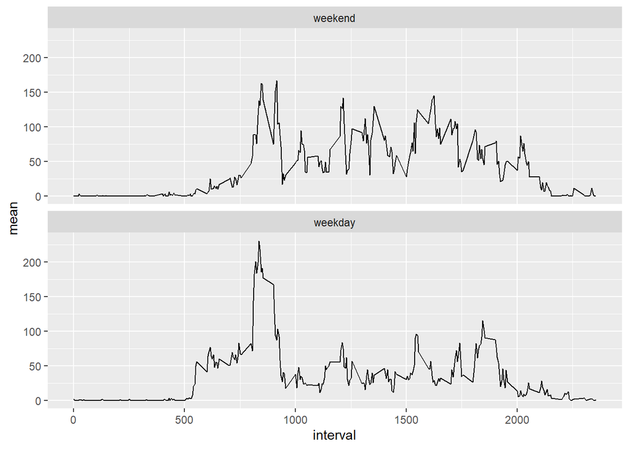

```r
##Separate into weekends and weekdays
togetherg <- group_by(together, interval, weekday) %>% summarize(mean = mean(steps, na.rm = TRUE))
d <- ggplot(togetherg, aes(interval, mean))+
  geom_line()
d + facet_wrap(~ weekday, nrow = 2, ncol = 1)
```